# week3AssignmentStatTesting

Matthew Onimus

3/20/2020

## Exercises from Attachments

Replication of exercises in assignment attachment.

```r
x <- rnorm(1000, mean = 0)

shapiro.test(x)
```

```
##
##  Shapiro-Wilk normality test
##
## data:  x
## W = 0.99625, p-value = 0.01654
```

```r
datatable(CO2)
```

|  | Plant | Type | Treatment | conc | uptake |
| --- | --- | --- | --- | --- | --- |
| 1 | Qn1 | Quebec | nonchilled | 95 | 16 |
| 2 | Qn1 | Quebec | nonchilled | 175 | 30.4 |
| 3 | Qn1 | Quebec | nonchilled | 250 | 34.8 |
| 4 | Qn1 | Quebec | nonchilled | 350 | 37.2 |
| 5 | Qn1 | Quebec | nonchilled | 500 | 35.3 |
| 6 | Qn1 | Quebec | nonchilled | 675 | 39.2 |
| 7 | Qn1 | Quebec | nonchilled | 1000 | 39.7 |
| 8 | Qn2 | Quebec | nonchilled | 95 | 13.6 |
| 9 | Qn2 | Quebec | nonchilled | 175 | 27.3 |
| 10 | Qn2 | Quebec | nonchilled | 250 | 37.1 |

[output cut: 74 more lines]

```r
y <- CO2[,5]

shapiro.test(y)
```

```
##
##  Shapiro-Wilk normality test
##
## data:  y
## W = 0.94105, p-value = 0.0007908
```

## R-Bloggers Example

Here I will recreate the r-bloggers example[https://www.r-bloggers.com/normality-and-testing-for-normality/] for testing normality.

**A seed should be set to ensure the random calls (`rnorm` and `sample`) produce the same results each time**

**The function in the blog is incorrect. The input either needs to be changed to `my.data` (currently it is `data`) or the reference call in the function needs to be updated to `data` (currently `my.data`). I have removed all the `my.data` calls from the function and replaced with `data` as that is the more convential way to code the function. If this function was called as it is written in the blog and `my.data` was not in the global environment, it would break.**

```r
set.seed(2)

#this function was not properly written in the blog post.  the input either needs to be my.data or the input call in the function needs to be data...
assignVector <- function(data, n = 1000) {

  p.5 <- replicate(n, expr = shapiro.test(sample(data, 5, replace=TRUE))$p.value)
  p.10 <- replicate(n, expr = shapiro.test(sample(data, 10, replace=TRUE))$p.value)
  p.1000 <- replicate(n, expr = shapiro.test(sample(data, 1000, replace=TRUE))$p.value)

  p.df <- cbind(p.5, p.10, p.1000)
  p.df <- as.data.frame(p.df)
  colnames(p.df) <- c("5 samples","10 samples","1000 samples")
  p.df.m <- melt(p.df)

  p.df.m <- transform(p.df.m, variable = factor(variable, levels = c("5 samples","10 samples","1000 samples")))
  return(p.df.m)
}

n.rand <- 100000
n.test <- 10000
my.data <- rnorm(n.rand)
p.df.m <- assignVector(my.data, n = n.test)
```

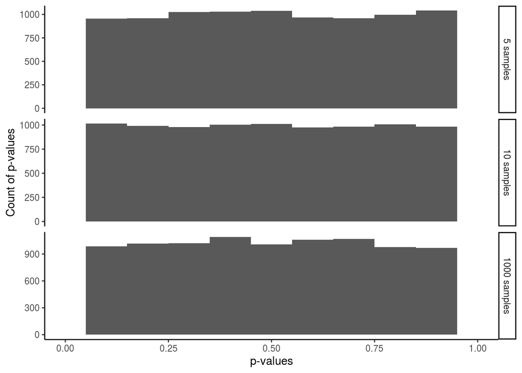

```r
ggplot(p.df.m, aes(x = value)) +
  geom_histogram(binwidth = 0.1) +
  facet_grid(variable ~ ., scales = 'free_y') +
  xlim(0,1) +
  theme_classic() +
  labs(
    x = "p-values",
    y = 'Count of p-values'
  )
```

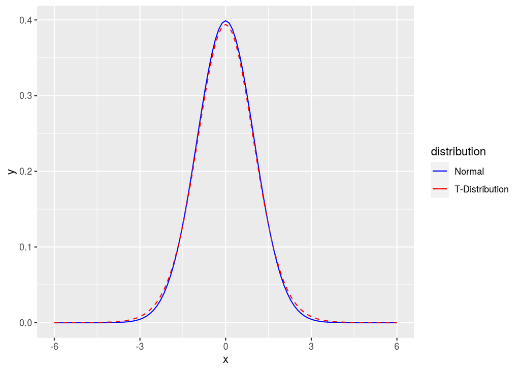

```r
ggplot(NULL, aes(x=x, colour = distribution)) +
  stat_function(fun=dnorm, data = data.frame(x = c(-6,6), distribution = factor(1))) +
  stat_function(fun=dt, args = list( df = 20), data = data.frame(x = c(-6,6), distribution = factor(2)), linetype = "dashed") +
  scale_colour_manual(values = c("blue","red"), labels = c("Normal","T-Distribution"))
```

```r
my.data <- rt(n.rand, df = 20)

p.df.m <- assignVector(my.data, n = n.test)
```

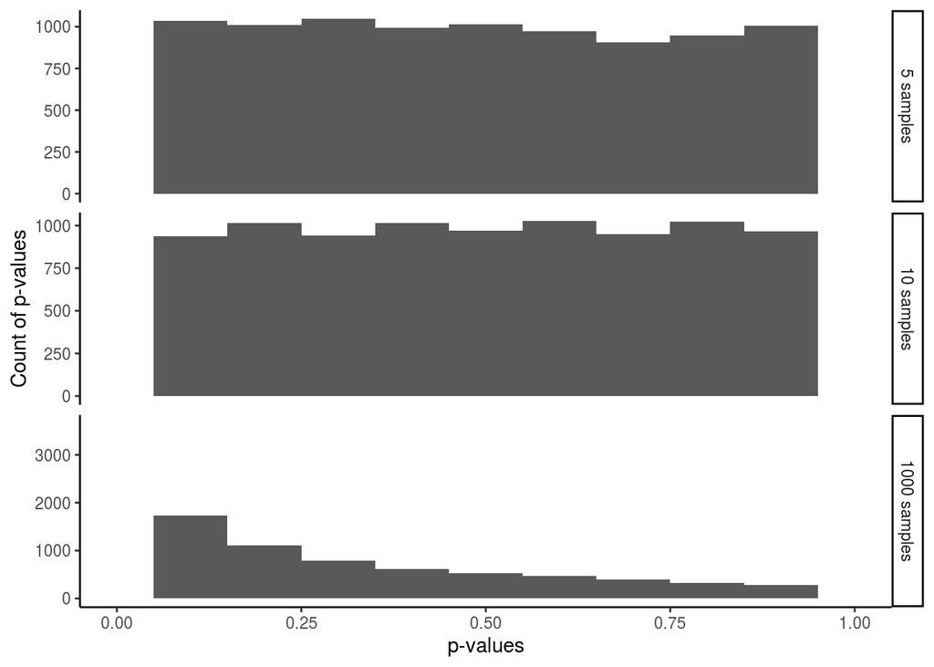

```r
ggplot(p.df.m, aes(x = value)) +
  geom_histogram(binwidth = 0.1) +
  facet_grid(variable ~ ., scales = 'free_y') +
  xlim(0,1) +
  theme_classic() +
  labs(
    x = "p-values",
    y = 'Count of p-values'
  )
```

```r
# testin the tails

my.data <- rt(n.rand, df = 20)
my.data2 <- rnorm(n.rand)

my.data <- my.data[which(my.data < 3 & my.data > -3)]

my.data <- c(my.data, my.data2[which(my.data2 < -3 | my.data2 > 3)])

p.df.m <- assignVector(my.data, n = n.test)
```

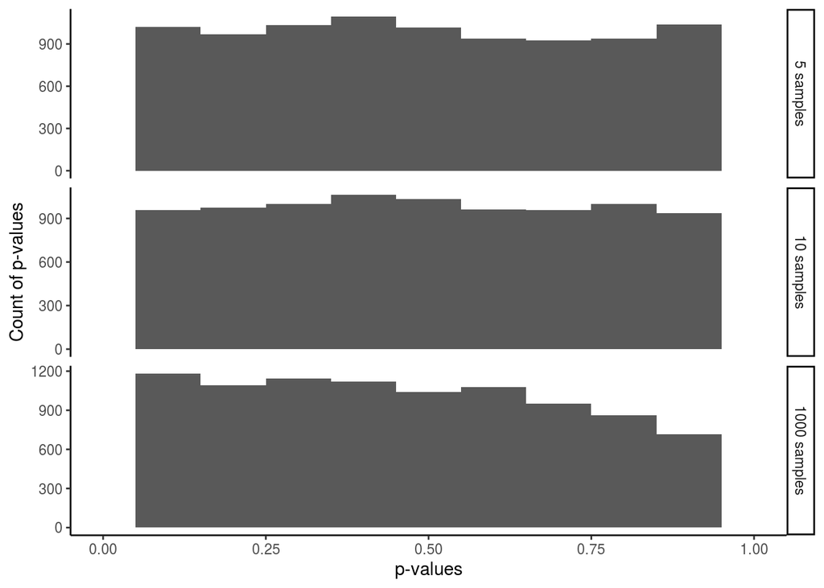

```r
ggplot(p.df.m, aes(x = value)) +
  geom_histogram(binwidth = 0.1) +
  facet_grid(variable ~ ., scales = 'free_y') +
  xlim(0,1) +
  theme_classic() +
  labs(
    x = "p-values",
    y = 'Count of p-values'
  )
```

```r
my.data <- rnorm(n.rand)
my.data2 <- rt(n.rand, df = 20)

my.data <- my.data[which(my.data < 3 & my.data > -3)]

my.data <- c(my.data, my.data2[which(my.data2 < -3 | my.data2 > 3)])


p.df.m <- assignVector(my.data, n = n.test)
```

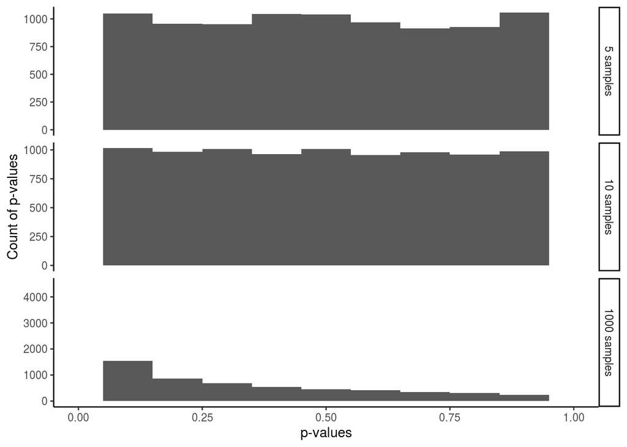

```r
ggplot(p.df.m, aes(x = value)) +
  geom_histogram(binwidth = 0.1) +
  facet_grid(variable ~ ., scales = 'free_y') +
  xlim(0,1) +
  theme_classic() +
  labs(
    x = "p-values",
    y = 'Count of p-values'
  )
```

```r
my.data <- rlnorm(n.rand, 0, 0.4)


p.df.m <- assignVector(my.data, n = n.test)
```

[figure not shown]

```r
ggplot(p.df.m, aes(x = value)) +
  geom_histogram(binwidth = 0.1) +
  facet_grid(variable ~ ., scales = 'free_y') +
  xlim(0,1) +
  theme_classic() +
  labs(
    x = "p-values",
    y = 'Count of p-values'
  )
```

**After working through this blog post, it is quite a mess without all steps worked out and things very poorly explained. The code is also poorly written with reusing variable names over and over again., IMO**